# Úvod do kvantitativní textové analýzy

Tadeášek

12/7/2021

# *Nejlepšejší návod na vstup do Matrixu*

Připrav si ručník, nepanikař, poděkuj rybám a jdem na to!

## Příprava Rka

Nejdřív je důležitý se na zákrok připravit, proto si nainstaluj tyhle zcela balíčky skrze příkaz: install.packages(“balíček”)

“SnowballC” -> klíčový pro “text stemming”  
“wordcloud” -> to je docela očividný, viď! vono to nebude tak těžký nakonec.  
“RColorBrewer” -> pro všechny visual driven jedince klíčovej balíček aneb vymaluj si svůj mráček “stopwords” -> databáze stop slov v různejch jazycích + dobrých stop slov pro stemming  
“quanteda” -> balíček, který využijeme pro odstranění bezvýznamnových slov - proč?: https://stackoverflow.com/questions/26899857/self-conflicting-stopwords-in-r-tm-text-mining + další skvělá dokumentace zde: https://quanteda.io/articles/pkgdown/quickstart.html#creating-a-corpus “readtext” -> čtení slov z .txt  
“quanteda.textplots” -> rozšíření quantedy pro tvorbu wordcloudů  
“quanteda.textstats” -> rozšíření quantedy pro tvorbu grafů z textu  
“ggplot2” -> snad ani nemusím představovat:-)

Po instalaci všechny balíčky zapni skrz příkaz: library(“balíček”). Pro milovníky oken se dají balíčky hledat a zapínat vpravo dole: https://i.imgur.com/8Z3MsGA.png

```r
library("quanteda")
```

```r
library("readtext")
library("stopwords")
library("SnowballC")
library("wordcloud")
library("RColorBrewer")
library("quanteda.textplots")
library("quanteda.textstats")
library("ggplot2")
```

## Příprava textu k mráčkování

Teď je ten moment, kdy chcem zjistit, co chceme zpracovávat. Já třeba žiju rád nebezpečně, takže jsem šel na infamous stránku Library Genesis (https://libgen.is/). Rozhodl jsem se zpracovat knihu z mého oblíbeného žánru magickýho realismu - Konec světa&Hardboiled Wonderland od Murakamiho.

Většina knih je na Libgenu ve formátu .epub. Já zvolil nejjednodušší cestu a jako vstup do celého procesu textového těžení jsem si zvolil .txt. Konverze je poměrně jednoduchá, využít se dá například tato služba: https://convertio.co/epub-txt/. Netřeba za tím hledat nástrahy, jde o přímočarý proces.

## Konečně kódujem, hurá

Textovej soubor s knížkou teda máme. Ten chceme naloadovat. Tady už zjistíme, že se můj kód mění od referečního, který používá knihovnu textmining (tm). Po intenzivním googlení jsem usoudil, že nejlepším nástrojem na kvantitativní textovou analýzu je quanteda. Ta má trochu jiné nástroje než tm, ale zas mi to pomohlo pochopit fungování Rka o něco lépe.

Nejdřív načteme slova z našeho textového souboru do datasetu:

```r
KonecSvěta <- readtext("~/GitHub/RStudio/data murakami/Murakami.txt")
```

Pokud nevíš, jak jednoduše vykopírovat cestu k souboru, tak je to tady:

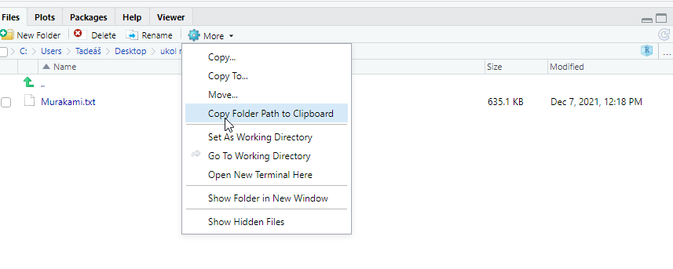

Teď budeme potřebovat Corpus. Výhoda quantedy je třeba v tom, že data v Corpusu při čištění nemění - využívá místo toho tokeny. Token se vytvoří takto:

```r
KorpusWonderland <- corpus(KonecSveta)
summary(KorpusWonderland)
```

```
## Corpus consisting of 1 document, showing 1 document:
##
##          Text Types Tokens Sentences
##  Murakami.txt 12571 144076     11856
```

Je vidět, že Corpus je teď zmatenej, potřebujeme mu říct, co v textu je, z čeho má tokeny vytvářet - obecně v Rku používáme vektory, který nám říkaj, co daná věc znamená - mohou to být čísla, data, jména, roky! V tomhle případě nám ale bude stačit jednoduchý charakterový vektor. - to je první část kódu

V druhé části si připravíme Tokeny, které potom můžeme dále čistit.

```r
as.character(KorpusWonderland)[2]
```

```
## <NA>
##   NA
```

```r
summary(KorpusWonderland, n = 1)
```

```
## Corpus consisting of 1 document, showing 1 document:
##
##          Text Types Tokens Sentences
##  Murakami.txt 12571 144076     11856
```

Nyní připravíme tokeny v samotném korpusu. Jde použít jen neinvazivní příkazy - použil jsem naprostou většinu z nich, více v dokumentaci o quantedě.

```r
tokens(KorpusWonderland, remove_numbers = TRUE, remove_punct = TRUE, remove_symbols = TRUE, remove_url = TRUE, remove_separators = TRUE)
```

```
## Tokens consisting of 1 document.
## Murakami.txt :
##  [1] "HARD-BOILED" "WONDERLAND"  "AND"         "THE"         "END"
##  [6] "OF"          "THE"         "WORLD"       "by"          "Haruki"
## [11] "Murakami"    "TRANSLATED"
## [ ... and 116,762 more ]
```

Teď si vytvořím separátní set tokenů - v tom je zase quanteda lepší než tm - TM zasahuje při čištění přímo do korpusu, kdežto v quantedě předcházíme případné ztrátě dat a progresu již takto. Následujícím příkazem vytváříme data set Tokeny, který obsahuje tokeny z našeho korpusu.

```r
Tokeny <- tokens(KorpusWonderland, remove_numbers = TRUE, remove_punct = TRUE, remove_symbols = TRUE, remove_url = TRUE, remove_separators = TRUE)
```

V dalším kroku chci, aby bylo všechno v lowercase, na to je tento příkaz (tady používám dokumentaci, nic složitého)

```r
MaleTokeny <- tokens_tolower(Tokeny, keep_acronyms = FALSE)
```

No a ted prichazi zajimavejsi cast. Chci se zbavit bezvyznamovych slow (a, the,…). Na to vyuziju balicek stopwords. Opět, balíček tm využívat externí stopwords neumí, už ten příkaz v sobě má a je dost na prd. V quantedě můžeme využít snowball stopwords databázi.

příkaz je následující - vyberu z malých tokenů ty, které odpovídají databázi stopwords od snowball a pak řeknu, že jejich označení znamená, že je odstraním

```r
CisteTokeny <- tokens_select(MaleTokeny, pattern = stopwords(language = "en", source = "snowball", simplify = TRUE), selection = "remove")
print(CisteTokeny)
```

```
## Tokens consisting of 1 document.
## Murakami.txt :
##  [1] "hard-boiled" "wonderland"  "end"         "world"       "haruki"
##  [6] "murakami"    "translated"  "japanese"    "alfred"      "birnbaum"
## [11] "haruki"      "murakami"
## [ ... and 57,085 more ]
```

Dostala ses až sem? Tak trocha egoboostu, tohle píšou v dokumentaci ke quantedě “Tokenizing texts is an intermediate option, and most users will want to skip straight to constructing a document-feature matrix”

Pokračujeme ale dál. Nyní si chci vybrat další slova, která se mi v CisteTokeny nelíbí. To udělám skrze arguemnt pattern:

```r
ManualniNiceni <- tokens_select(CisteTokeny, pattern = c("said", "like", "one", "say", "can", "go", "right"), selection = "remove")
```

## Matrix?

Teď mám tedy vyčištěné tokeny a připravený korpus, vzhůru do Matrixu!

Na to je příkaz následující, pak si jen vytisknem pár znaků, abychom se ujistili, že to je správně:

```r
MatrixWonderland <- tokens(ManualniNiceni) %>%
  dfm()
MatrixWonderland[, 1:30]
```

```
## Document-feature matrix of: 1 document, 30 features (0.00% sparse) and 0 docvars.
##               features
## docs           hard-boiled wonderland end world haruki murakami translated
##   Murakami.txt           1          2 104   196      3        3          3
##               features
## docs           japanese alfred birnbaum
##   Murakami.txt        9      2        2
## [ reached max_nfeat ... 20 more features ]
```

Šikovnou funkcí je wordstem - stemming - odstraníme přebytečná písmenka a získáme tím jen kořeny slov:

```r
MatrixWonderland <- dfm_wordstem(MatrixWonderland, language = ("english"))
```

Teď se podíváme na naše top slova:

```r
topfeatures(MatrixWonderland, 80)
```

```
##      time      know     thing       old       get      look    shadow      back
##       348       321       271       255       249       248       238       231
##       now      hand      just     world       ask     skull      come      even
##       218       211       203       201       198       197       196       189
##     think      wall       way       got      mind      take       eye     light
##       186       184       182       177       175       172       172       171
##      head      want      much    someth       say       see      well       man
##       165       164       163       163       161       160       159       158
##      make       two     sound      noth      town     still  gatekeep      tell
##       158       153       153       149       149       146       142       140
##      open      long      door     never    around      seem     place        go
##       138       138       136       133       132       131       126       125
##       day      work        us      read       end grandfath     first   thought
##       124       123       122       120       118       117       114       114
##      left      turn      good      went      girl      must    system professor
##       113       113       112       111       111       110       110       109
##      wood      leav    realli      need     littl     water     three      away
##       105       104       104       104       102       102       101       101
##      next       put     anyth      mean     anoth   everyth      live      feel
##       100        99        99        98        97        96        96        94
```

## Vizualizace: mráčky a grafíky

Tak! A je to tady, teď už jdeme dělat mráček. Nastavíme si seed, aby se nám generoval stále stejně, když ho budeme chtít upravovat. Argumenty jsou docela jasné, v dokumentaci dobře popsané. Využíváme tu na barvení knihovnu RColorBrewer. Abych neměl stejný graf jako všichni, tak jsem využil sekvenční paletu s co nejvyšším množstvím odlišení, v tomto případě je barev 9.

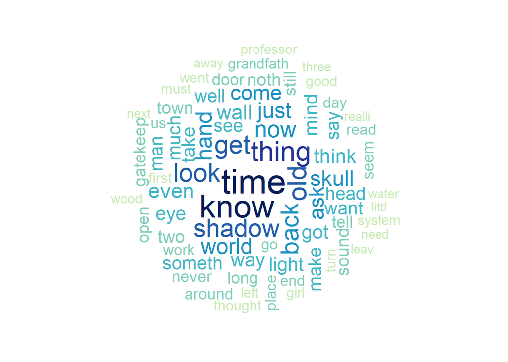

```r
set.seed(100)
textplot_wordcloud(MatrixWonderland, min_count = 100, random_order = FALSE, rotation = 0.25, color = RColorBrewer::brewer.pal(9, "YlGnBu"))
```

Pak jsem chtěl udělat ještě grafík. Dokumentace tady: https://quanteda.io/articles/pkgdown/examples/plotting.html Jestli ses dostal/a až sem, tak už to vůbec není těžké pochopit:-)

```r
FrequencyPlot <- textstat_frequency(MatrixWonderland, n = 100)
FrequencyPlot$feature <- with(FrequencyPlot, reorder(feature, -frequency))
```

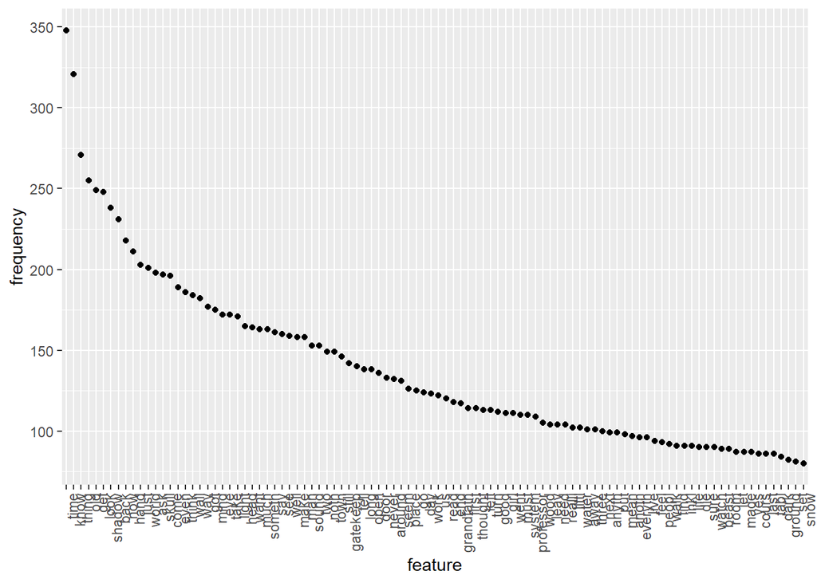

```r
ggplot(FrequencyPlot, aes(x = feature, y = frequency)) +
  geom_point() +
  theme(axis.text.x = element_text(angle = 90, hjust = 1))
```

# Odkazy na zdroje

Neseřazeno, jak jsem to pomíchal, tak to sem posílám

https://quanteda.io/articles/pkgdown/examples/plotting.html  
https://stackoverflow.com/questions/47039236/how-to-keep-wordcloud-layout-in-r  
https://stackoverflow.com/questions/26899857/self-conflicting-stopwords-in-r-tm-text-mining -> proto quanteda, tm sucks!  
https://quanteda.io/articles/pkgdown/comparison.html -> proto quanteda, je prostě dobrá! na kvantitativní analýzu textu není nic lepšího  
https://quanteda.io/reference/tokens.html -> Jak používat tokeny  
https://tutorials.quanteda.io/basic-operations/tokens/tokens_select/ -> jak vybrat a odstranit tokeny, který nechcem  
https://quanteda.io/reference/stopwords.html -> stopwords

https://quanteda.io/reference/tokens_tolower.html -> jak hodit vše do lowercase

https://quanteda.io/articles/quickstart.html -> základní návod na to, jak nahrát .txt, jak ho přečíst, jak ho převést do corpusu, jak pracovat s tokenama a jak udělat wordcloud případně vizualizovat ggplotem

https://quanteda.io/articles/pkgdown/examples/plotting.html -> širší možnosti vizualizace

https://quanteda.io/reference/textplot_wordcloud.html -> values pro wordcloud v quantedě

https://www.datanovia.com/en/blog/the-a-z-of-rcolorbrewer-palette/#display-all-brewer-palettes -> rcolorbrewer palety

https://quanteda.io/articles/pkgdown/replication/digital-humanities.html -> digital humanities porno! nástroje, který nám ukazoval Josef jsou skvělý v tom, jak jsou jednoduchý, ale tohle toho umí tolik! TOLIK!

Palety textově: Sequential palettes (first list of colors), which are suited to ordered data that progress from low to high (gradient). The palettes names are : Blues, BuGn, BuPu, GnBu, Greens, Greys, Oranges, OrRd, PuBu, PuBuGn, PuRd, Purples, RdPu, Reds, YlGn, YlGnBu YlOrBr, YlOrRd.  
Qualitative palettes (second list of colors), which are best suited to represent nominal or categorical data. They not imply magnitude differences between groups. The palettes names are : Accent, Dark2, Paired, Pastel1, Pastel2, Set1, Set2, Set3.  
Diverging palettes (third list of colors), which put equal emphasis on mid-range critical values and extremes at both ends of the data range. The diverging palettes are : BrBG, PiYG, PRGn, PuOr, RdBu, RdGy, RdYlBu, RdYlGn, Spectral

## Tipy na konec

instalace externích repositories se provádí skrz balíček “remotes”